# Descriptive Analysis & Hypothesis Testing

### Machine Learning and Related Applications Assignment

#### K.C.L.Piyasiri- COBSCDS221P-017

**Note:** Below, Descritive Analysis and Hypothesis Testing are derived according to the following criteria of data:

- **Departments: Grocery, Beverages, Chilled**
- **Stores: A, B, C, D, E**

```python
%run ./Descriptive_analysis_utilities.ipynb
```

## Part 1: Descriptive Analysis

### Graph I: Distribution of Sales by Month

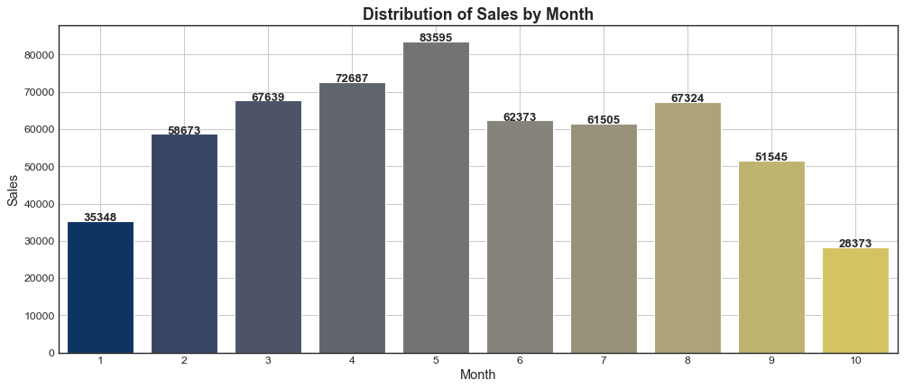

```python
monthly_sales_plot(trans, item);
```

> The graph shows an upward trend from Month 1 to Month 5, with consistent growth in each consecutive month. However, there is a significant decrease in total sales in Month 6 and Month 7. The last two months, Month 9 and Month 10, show a decline in sales compared to previous months. Overall, the data suggests a mixed pattern with both periods of growth and decline.

### Graph II: Distribution of Sales by the Week of Month

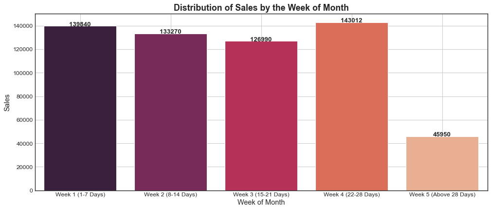

```python
week_month_sales_plot(trans, item);
```

> The graph exhibits the variability of sales throughout the weeks of the month. Total sales were highest in Week 4 at 143,012 units, illustrating the salary cycle of the customers. In addition, sales of 45,950 units were recorded in Week 5 beyond the 28-day period at the end of the month. However, there is a slight declining trend in sales from Week 1 to Week 3. The sales were decreased from 139,840 units to 126,990 units during this period.

### Graph III: Distribution of Sales by the Date of Month

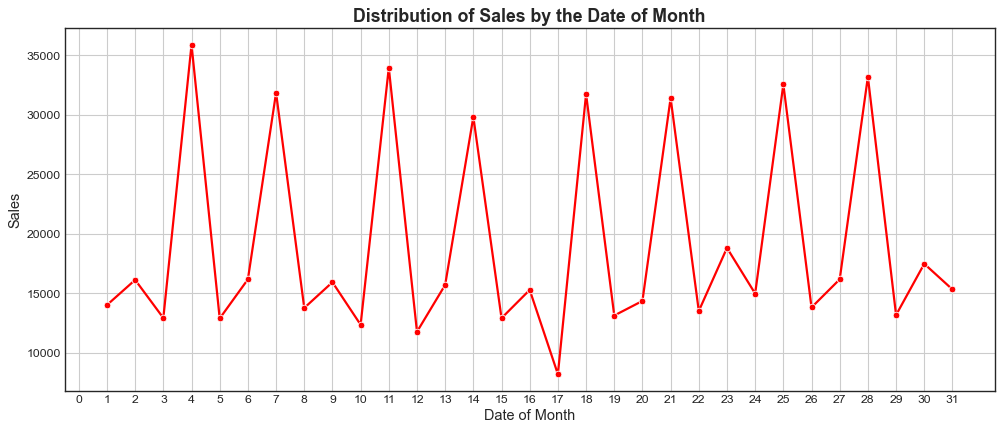

```python
date_month_sales_plot(trans, item);
```

> The data exhibits the variability of sales throughout the month. The highest sales are observed on Day 4 with 35,903 units, followed by peaks on Day 11, Day 28, and Day 25 with sales of 33,965 units, 33,202 units, and 32,571 units, respectively. The lowest sales in the given data were recorded on Day 17, with a total of 8,183 units. Overall, the sales distribution fluctuates across the month, with no consistent upward or downward trend observed.

### Graph IV: Distribution of Sales by the Day of Week

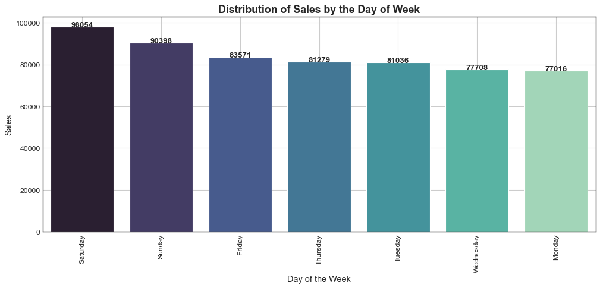

```python
weekday_sales_plot();
```

> The plot represents the distribution of sales for each day of the week. As expected, the weekend recorded the highest sales quantity distribution. Saturday records the highest sales quantity at 98,054 units, followed by Sunday with 90,398 units and Friday with 83,571 units. Monday has the lowest sales quantity at 77,016 units. Overall, the data suggests a relatively consistent pattern of sales quantities throughout the week, with weekends showing slightly higher sales compared to weekdays. This pattern could be attributed to increased consumer activity or more free time available during the weekends, leading to higher sales.

### Graph V: Distribution of Sales by the Outlet

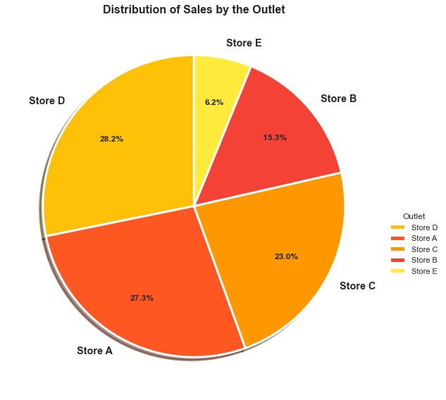

```python
outlet_sales_plot(trans, item);
```

> The above pie chart represents the total sales distribution for different stores, with Outlet D having the highest sales at 28.2%. Outlet A follows closely behind with 27.3%, while Outlet C records a 23% sales distribution. Outlet E has the lowest sales distribution among the given outlets, with 6.2%. It suggests that Outlet D and Outlet A are the top-performing outlets in terms of sales, likely indicating a higher level of customer engagement, marketing effectiveness, or product popularity in those stores.

### Graph VI: Distribution of Sales by the Top Ten Item Categories

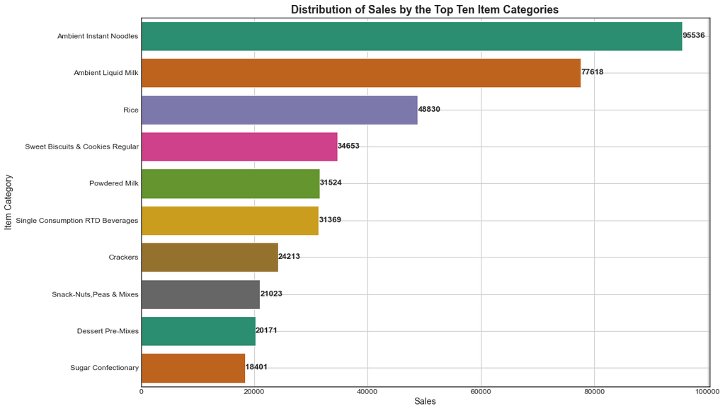

```python
sales_items_plot(trans, item);
```

> The above graph represents the top ten selling item categories. It reveals that the top-selling item categories are "Ambient Instant Noodles" and "Ambient Liquid Milk," indicating their popularity among consumers. "Rice" also demonstrates significant sales, likely due to its essential status as a staple food. The remaining item categories, such as "Sweet Biscuits & Cookies Regular," "Powdered Milk," and "Single Consumption RTD Beverages," contribute to the overall sales volume at slightly lower levels.

### Graph VII: Distribution of Day of Week Sales by the Item Department

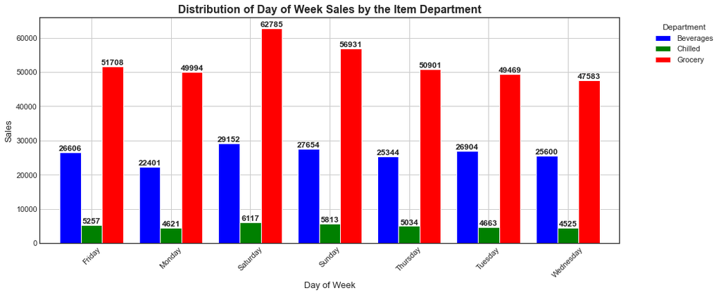

```python
day_sales_department_plot();
```

### Graph VIII: Distribution of Top 5 Fast Moving Items in each Department and in each Outlet

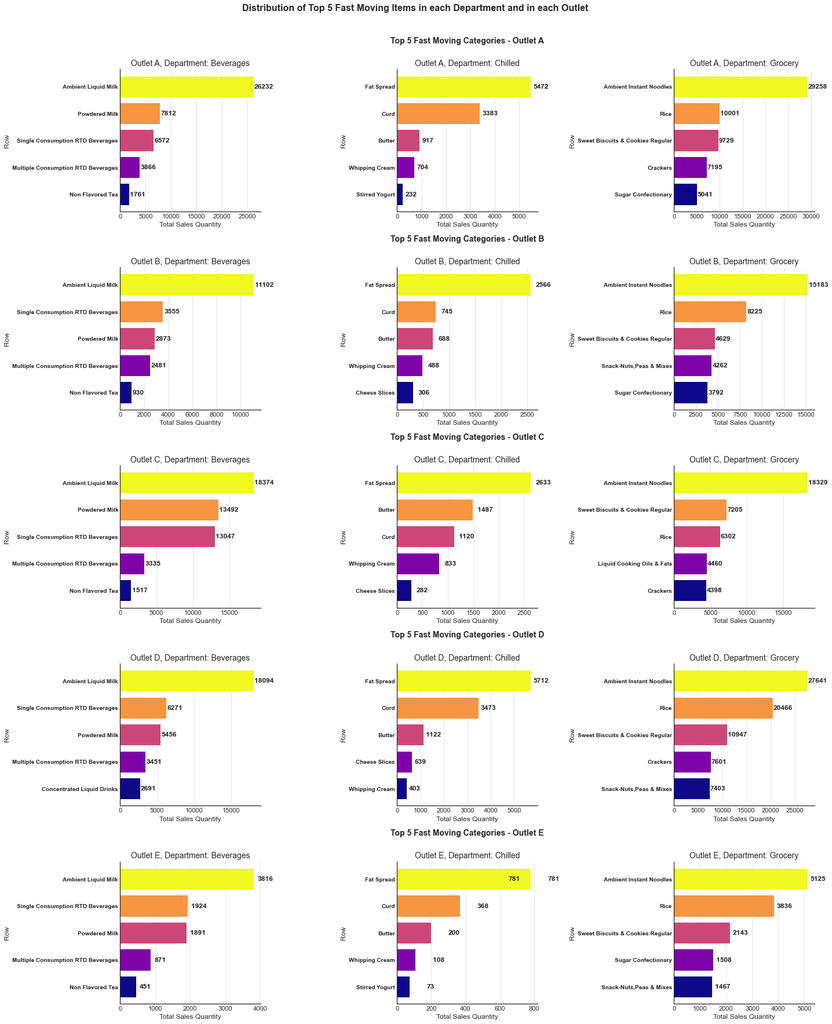

```python
top_5_fast_moving_plot(fast_moving_category);
```

### Graph IX: Distribution of Sales by the Outlet Area

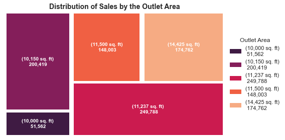

```python
sales_outlet_area_plot();
```

### Graph X: Distribution of Sales by the Number of Outlet Parking Lots

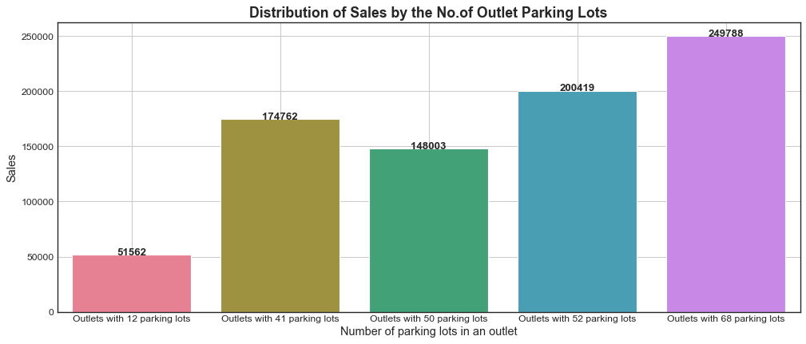

```python
sales_outlet_parking_plot(trans, item, store);
```

> The above graph shows that the outlet with 68 parking lots stands out as the top-performing one, with total sales reaching 249,788. It is closely followed by the outlet with 52 parking lots, which recorded sales of 200,419. Similarly, outlets with 50 and 41 parking lots also demonstrate significant sales figures, with total sales amounting to 148,003 and 174,762, respectively. The outlet with the lowest number of parking lots, 12, shows relatively lower sales compared to the others, reaching a total of 51,562.

### Graph XI: Distribution of Sales by the Outlet Profile Category

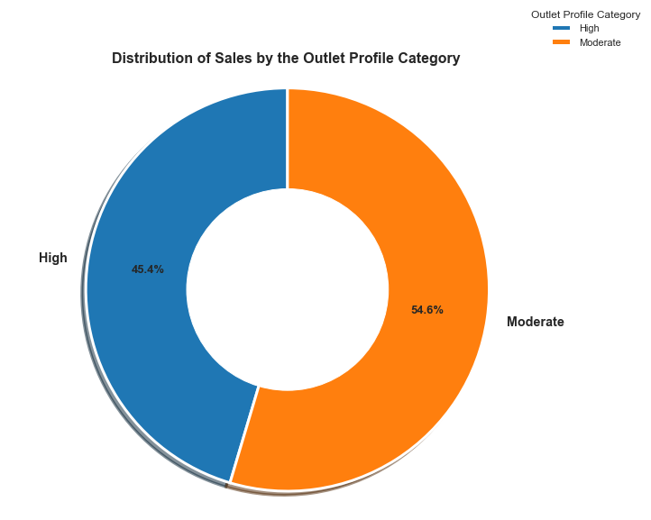

```python
sales_outlet_profile_plot(trans, item, store);
```

> The above donut chart shows that outlets categorized as "Moderate" have higher sales volumes compared to outlets categorized as "High." Outlets with a "Moderate" profile category recorded total sales amounting to 450,207, while outlets classified as "High" profile category had total sales of 374,327.

## Part 2: Hypothesis Testing

### Hypothesis 1: The combined total sales in the fourth week and the fifth week are higher than the other individual weeks because of the salaray cycle of the customers.

> **Null Hypothesis (H0) :** The combined total sales in the fourth week and the fifth week are not higher than the individual weeks.  
> **Alternative Hypothesis (H1) :** The combined total sales in the fourth week and the fifth week are higher than the individual weeks.

Comparing the combined total sales of the fourth and fifth weeks with the sales of the individual weeks:

- Total sales for the combined fourth and fifth weeks: 143,012 + 45,950 = 188,962 units
- Total sales for Week 1: 139,840 units
- Total sales for Week 2: 133,270 units
- Total sales for Week 3: 126,990 units

Based on the data, we can observe that the combined total sales of the fourth and fifth weeks are indeed higher than the sales in each individual week

**Therefore, we can reject the null hypothesis (H0) and conclude that the combined total sales in the fourth week and the fifth week are higher than the individual weeks.**

### Hypothesis 2: The sales quantity distribution on weekends (Saturday and Sunday) is higher than the sales quantity distribution on weekdays (Monday to Friday).

> **Null Hypothesis (H0) :** The sales quantity distribution on weekends is not higher than the sales quantity distribution on weekdays.  
> **Alternative Hypothesis (H1) :** The sales quantity distribution on weekends is higher than the sales quantity distribution on weekdays

Comparing the sales quantity distribution on weekends (Saturday and Sunday) with the sales quantity distribution on weekdays (Monday to Friday):

- Sales quantity on Saturday: 98,054 units
- Sales quantity on Sunday: 90,398 units
- Sales quantity on Friday: 83,571 units
- Sales quantity on Thursday: 81,279 units
- Sales quantity on Tuesday: 81,036 units
- Sales quantity on Wednesday: 77,708 units
- Sales quantity on Monday: 77,016 units

Based on the data, we can observe that the sales distribution quantity on weekends is higher than the sales distribution quantity on weekdays.

**Therefore, we can reject the null hypothesis (H0) and conclude that the sales quantity distribution on weekends is higher than the sales quantity distribution on weekdays.**

### Hypothesis 3: The larger the outlet area, the higher the sales quantity distribution.

> **Null Hypothesis (H0) :** The sales quantity is not higher in larger outlet areas.  
> **Alternative Hypothesis (H1) :** The sales quantity is higher in larger outlet areas.

Comparing the sales quantities in different outlet areas:

- Outlet area 10000: 51,562
- Outlet area 10150: 200,419
- Outlet area 11237: 249,788
- Outlet area 11500: 148,003
- Outlet area 14425: 174,762

```python
correlation_coefficient_1, p_value_1 = outlet_area_correlation_analysis()

print('Correlation coefficient:', round(correlation_coefficient_1,3))
print('P-value:', round(p_value_1, 3))
```

```
Correlation coefficient: 0.245
P-value: 0.691
```

The correlation coefficient of 0.245 indicates a weak positive correlation between the outlet area in sq. ft. and total sales. However, the p-value of 0.691 is greater than the significance level of 0.05, indicating that we do not have sufficient evidence to conclude that the correlation is statistically significant.

**Therefore, we can not reject the null hypothesis (H0) and don't have sufficient evidence to conclude that the sales quantity is higher in larger outlet areas.**

### Hypothesis 4: The higher the outlet number of parking lots, the higher the sales quantity distribution.

> **Null Hypothesis (H0) :** The sales quantity is not higher when there are a high number of outlet parking lots.  
> **Alternative Hypothesis (H1) :** The sales quantity is higher when there are a high number of outlet parking lots.

Comparing the sales quantities in different numbers of outlet parking lots:

- Outlet parking lots 12: 51,562
- Outlet parking lots 41: 174,762
- Outlet parking lots 50: 148,003
- Outlet parking lots 52: 200,419
- Outlet parking lots 68: 249,788

Based on the data, it appears that the sales quantity distribution is indeed higher in outlets with a higher number of outlet parking lots (outlet parking lots 52, 68) compared to outlets with a lower number of outlet parking lots (outlet parking lots 12, 41).

However, to determine the extent to which they are associated, let's calculate the correlation coefficient between the outlet number of parking lots and the sales quantity.

```python
correlation_coefficient_2, p_value_2 = outlet_parking_correlation_analysis()

print('Correlation coefficient:', round(correlation_coefficient_2,3))
print('P-value:', round(p_value_2, 3))
```

```
Correlation coefficient: 0.956
P-value: 0.011
```

The correlation coefficient of 0.956 indicates a strong positive correlation between the outlet number of parking lots and the sales quantity. The p-value of 0.011 is less than the significance level of 0.05, indicating that the correlation is statistically significant.

**Therefore, we can reject the null hypothesis and conclude that the sales quantity is higher when there are a high number of outlet parking lots.**

### Hypothesis 5: The sales quantity is higher for outlets with a high outlet customer profile category compared to outlets with a moderate outlet customer profile category.

> **Null Hypothesis (H0) :** The sales quantity is not higher for outlets with a high outlet profile category compared to outlets with a moderate outlet profile category.  
> **Alternative Hypothesis (H1) :** The sales quantity is higher for outlets with a high outlet profile category compared to outlets with a moderate outlet profile category.

Comparing the total sales for outlets with a high outlet profile category and outlets with a moderate outlet profile category using the data provided:

- Sales for outlets with a high outlet profile category: 374,327
- Sales for outlets with a moderate outlet profile category: 450,207

Based on the data, it appears that the sales quantity is higher for outlets with a moderate outlet profile category compared to outlets with a high outlet profile category.

**Therefore, we can not reject the null hypothesis (H0) and an not conclude that the sales quantity is higher for outlets with a high outlet profile category compared to outlets with a moderate outlet profile category.**